# Porcentajes y regla de 3 simple

## Repaso de como calcular porcentajes con fracciones

Puedes repasarlo con este [video](https://www.youtube.com/watch?v=TGyHGwhS90A&list=PLFx6eqvnPSu6-G9r2762XHiUJOoad0CZA&index=1) poniendo atención a como se pueden simplificar numeradores y denominadores.

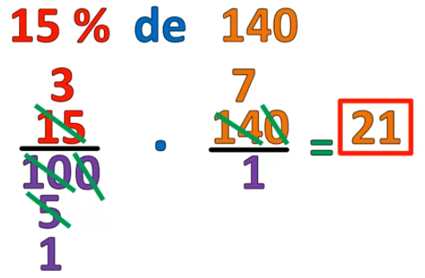

Simplificar las fracciones. Fuente: Canal Youtube Aprendiendo Matemática

## Actividad 1

Calcula los siguientes porcentajes usando fracciones y simplificándolas:

**1.** 30% de 150

**2.** 40% de 1500

**3.** 120% de 100

**4.** 35% de 500

**5.** 150% de 1000

## Porcentajes con regla de tres

La **regla de tres** es una técnica matemática para resolver problemas de proporciones.

**Ejemplo:** ¿Cuánto es el 15% de 300?

- *Paso 1:* Plantear la proporción

  100% ───── 300

  15% ───── x
- *Paso 2:* Aplicar regla de tres

  $x = \frac{15 \times 300}{100}$
- *Paso 3:* Simplifica como si fueran fracciones

  $x = \frac{15 \times 3}{1} = 45$

**Resumen:**

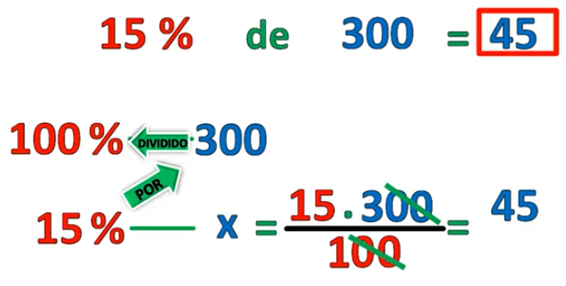

Fuente: Canal Youtube Aprendiendo Matemática

Puedes repasar este tema [aquí](https://www.youtube.com/watch?v=N473Ivvi0a4&list=PLFx6eqvnPSu6-G9r2762XHiUJOoad0CZA&index=5).

## Actividad 2

Calcular aplicando regla de 3 simple y simplificando:

**1.** 10% de 200

**2.** 20% de 200

**3.** 200% de 1000

**4.** 35% de 6500

**5.** 150% de 2500

**6.** 82% de 3500

## Cálculo del porcentaje que representa una cantidad (Regla de 3)

Supón que estuviste viendo los autos que pasan por la ruta y de 150 que pasaron 37 eran de color azul. ¿Qué porcentaje de los autos es azul?

Hay varios modos de resolver esto. Aquí vamos a resolverlo aplicando la regla de 3 simple:

**Planteo:**

150 autos ───── 100%

37 autos ───── x

**Resolución:**

$x = \frac{37 \times 100}{150}$

$x = \frac{37 \times 10}{15} = \frac{370}{15} = 24,7\%$

Puedes repasar esto [aquí](https://www.youtube.com/watch?v=-9x_d3dX5kA&list=PLFx6eqvnPSu6-G9r2762XHiUJOoad0CZA&index=16)

## Actividad 3

Resolver aplicando regla de 3 simple:

**1.** Juan compró 20 caramelos surtidos. Si 8 son de frutilla ¿qué porcentaje representan los caramelos de frutilla?

**2.** En un aula de 43 alumnos aprobaron una prueba solo 12 ¿Qué porcentaje aprobó la prueba?

**3.** Se presentaron 200 competidores a una maratón. De todos ellos solo 15 cruzaron la meta en menos de 3 hs. Si no hubo ningún abandono ¿qué porcentaje cruzó la meta en más de 3 horas?